# Topic 7: Capital Asset Pricing Model

Billy

2022-09-21

# Capital Asset Pricing Model

Investors are **risk averse** meaning they are reluctant to take risks, because of this they prefer less risky portfolios

## Risk preference - Portfolios

Portfolio A *dominates* Portfolio B if:

- $E[r_p(A)] \ge E[r_p(A)]$
- $\sigma(r_p(A)) \le \sigma(r_p(A))$

The subset of feasible portfolios with the lowest risk levels at each level of expected portfolio return are known as the minimum variance portfolios and form the **minimum variance frontier**

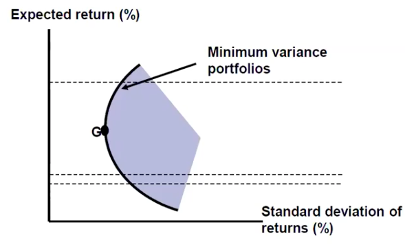

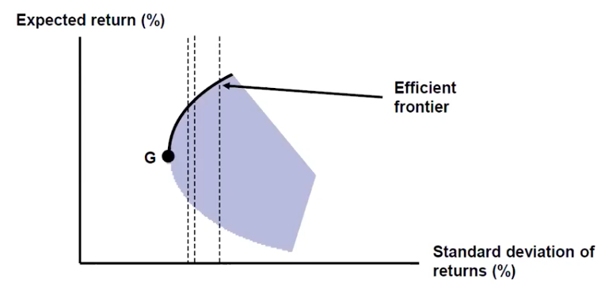

Based on this analysis, a rational investor will only choose portfolios on the efficient frontier – but which portfolio?

The portfolio chosen will depend on each individual investor’s attitude toward risk:

- Those who are more risk-averse will choose portfolios close to point G – these portfolios have less risk and lower returns.
- Those who are less risk-averse will choose portfolios further to the right on the efficient frontier – these portfolios offer higher expected returns but carry greater risk.

### Introduction of Risk Free Asset

The introduction of a risk-free asset ($\sigma$ = 0) expands the risk- return opportunities available for investment. New sets of feasible portfolios now exist.

- Each of the new sets of feasible portfolios is represented by a straight line from the risk-free asset to a portfolio on the efficient frontier.
- The position of each portfolio on these lines depends on the weighting of the risk-free asset and the risky asset in the portfolio

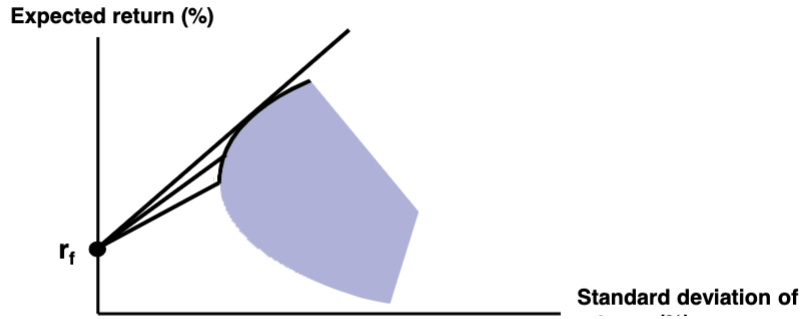

- You want the portfolio with the highest gradient:

## The CAPM

$$r_{p} = r_{f} + \frac{r_{m} -
r_{f}}{\sigma_{m}}\sigma_{p}$$

which is rewritten as:

$$r_{p} = r_{f} +
(r_{m}-r_{f})\frac{\sigma_{p}}{\sigma_{m}}$$

where:

- $r_{p}, r_{m}$ & $r_{f}$ represent the return on the portfolio, market and risk free asset
- $\sigma_{p}$ & $\sigma_{m}$ represent the SD of the portfolio and the market

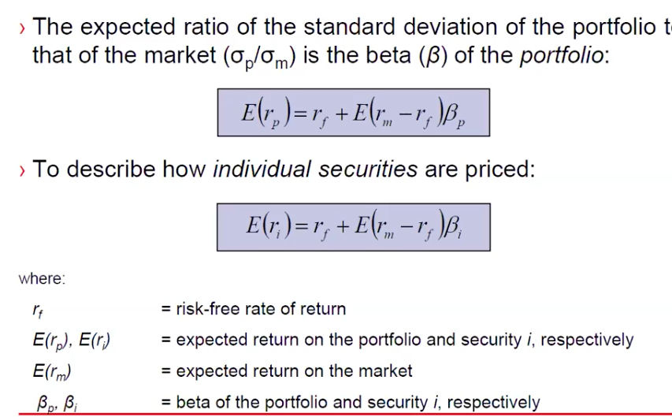

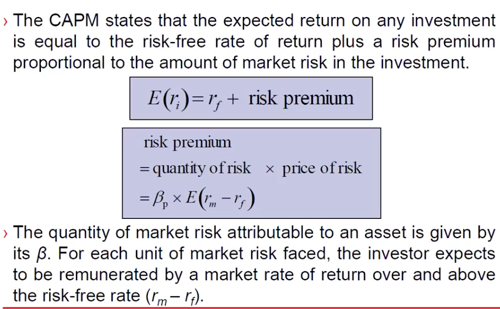

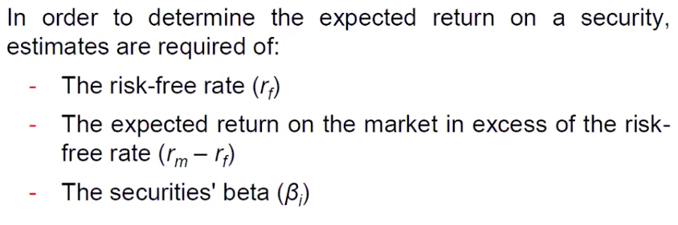

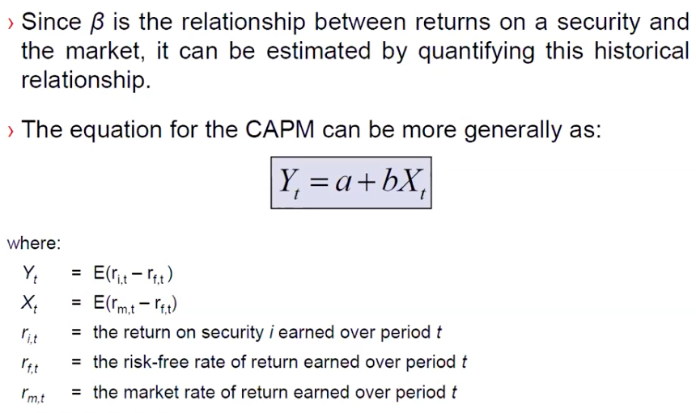

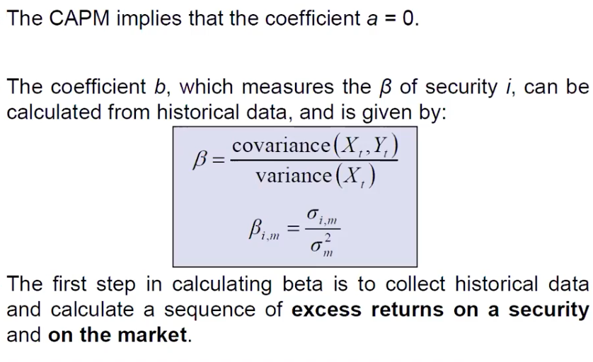

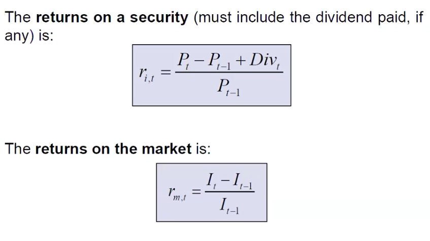